# rmarkdown

2023-02-16

```
## [1] "/Users/chloe/Desktop/INFO201/ps05-rmarkdown-plot"
```

```
##   iso3  name iso2   region                      sub.region intermediate.region
## 1  ABW Aruba   AW Americas Latin America and the Caribbean           Caribbean
## 2  ABW Aruba   AW Americas Latin America and the Caribbean           Caribbean
## 3  ABW Aruba   AW Americas Latin America and the Caribbean           Caribbean
##   time totalPopulation fertilityRate lifeExpectancy childMortality
## 1 1960           54211         4.820         65.662             NA
## 2 1961           55438         4.655         66.074             NA
## 3 1962           56225         4.471         66.444             NA
##   youthFemaleLiteracy youthMaleLiteracy adultLiteracy GDP_PC accessElectricity
## 1                  NA                NA            NA     NA                NA
## 2                  NA                NA            NA     NA                NA
## 3                  NA                NA            NA     NA                NA
##   agriculturalLand agricultureTractors cerealProduction fertilizerHa      co2
## 1               NA                  NA               NA           NA 11092.67
## 2               20                  NA               NA           NA 11576.72
## 3               20                  NA               NA           NA 12713.49
##   greenhouseGases   co2_PC pm2.5_35 battleDeaths
## 1              NA 204.6204       NA           NA
## 2              NA 208.8228       NA           NA
## 3              NA 226.1181       NA           NA
```

```
## There are 25 columns and 13055 rows.
```

```
## There are 253 different iso3 codes.
```

```
## There are 249 different iso2 codes.
```

```
## There are 250 different country names.
```

```
## # A tibble: 249 × 2
##    iso2      n
##    <chr> <int>
##  1 ""        2
##  2 "AD"      1
##  3 "AE"      1
##  4 "AF"      1
##  5 "AG"      1
##  6 "AI"      1
##  7 "AL"      1
##  8 "AM"      1
##  9 "AO"      1
## 10 "AQ"      1
## # … with 239 more rows
```

There are no Countries that share the same iso2 code. Only the unamed countries are the same.

```
## # A tibble: 250 × 2
##    name                      n
##    <chr>                 <int>
##  1 ""                        4
##  2 "Afghanistan"             1
##  3 "Albania"                 1
##  4 "Algeria"                 1
##  5 "American Samoa"          1
##  6 "Andorra"                 1
##  7 "Angola"                  1
##  8 "Anguilla"                1
##  9 "Antarctica"              1
## 10 "Antigua and Barbuda"     1
## # … with 240 more rows
```

```
##             n
## 1     CHANISL
## 2 NLD_CURACAO
```

These tables show the number of iso3 codes that share the same country name and the names of the iso3 codes that share the name.

```
## [1] 2019
```

```
## [1] 1960
```

```
## # A tibble: 60 × 2
##     time `length(co2)`
##    <int>         <int>
##  1  1960            60
##  2  1961            60
##  3  1962            58
##  4  1963            57
##  5  1964            51
##  6  1965            51
##  7  1966            51
##  8  1967            51
##  9  1968            51
## 10  1969            51
## # … with 50 more rows
```

This table shows all of the CO2 emission data that are missing by year.

```
## # A tibble: 3 × 2
##    time `length(co2)`
##   <int>         <int>
## 1  2017           217
## 2  2018           217
## 3  2019           217
```

This table shows the three years with the most CO2 emission data missing.

```
## # A tibble: 60 × 2
##     time `length(co2_PC)`
##    <int>            <int>
##  1  1960               60
##  2  1961               60
##  3  1962               58
##  4  1963               57
##  5  1964               51
##  6  1965               51
##  7  1966               51
##  8  1967               51
##  9  1968               51
## 10  1969               51
## # … with 50 more rows
```

This table shows all of the CO2 emission data per capita that is missing by year.

```
## # A tibble: 3 × 2
##    time `length(co2_PC)`
##   <int>            <int>
## 1  2017              217
## 2  2018              217
## 3  2019              217
```

This table shows the three years with the most CO2 PC emission data missing.

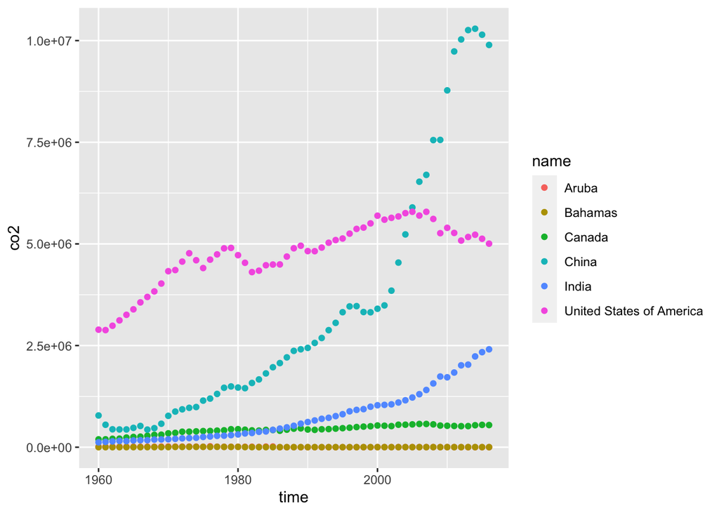

This is a graph of the total CO2 emissions from the US, China, India, Canada, Aruba, and the Bahamas from 1960 to 2019. Each country seems to be regulating CO2 emissions in very different patterns. However, the general trend of CO2 emissions over the years is upward.

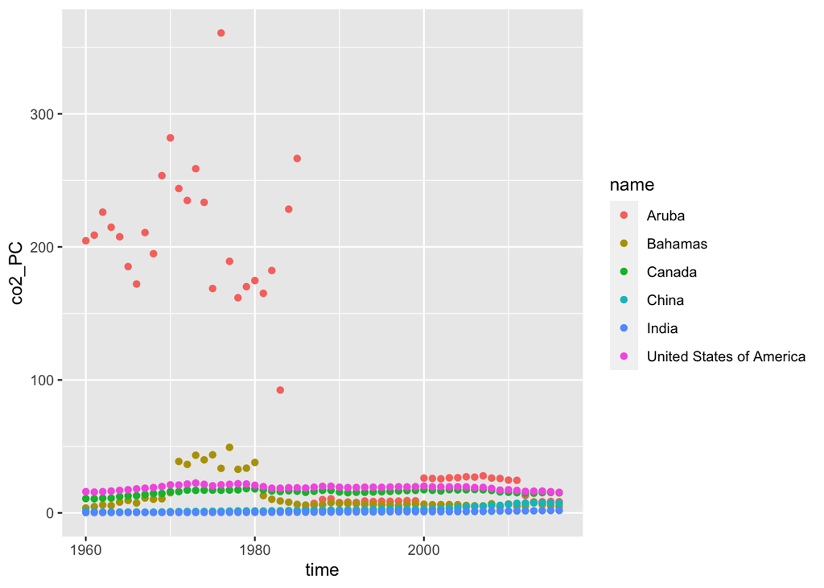

This is a graph of the CO2 emissions per capita from the US, China, India, Canada, Aruba, and the Bahamas from 1960 to 2019. The trends for CO2 emissions per capita seem to be pretty steady for all of the countries expect for Aruba.

```
## # A tibble: 294 × 3
## # Groups:   time [57]
##     time region   average_value
##    <int> <chr>            <dbl>
##  1  1960 Africa           0.291
##  2  1960 Americas         7.15
##  3  1960 Asia             1.74
##  4  1960 Europe           5.77
##  5  1960 Oceania          2.73
##  6  1961 Africa           0.300
##  7  1961 Americas         7.38
##  8  1961 Asia             2.06
##  9  1961 Europe           5.92
## 10  1961 Oceania          2.85
## # … with 284 more rows
```

These are the average CO2 emissions per capita for each region every year.

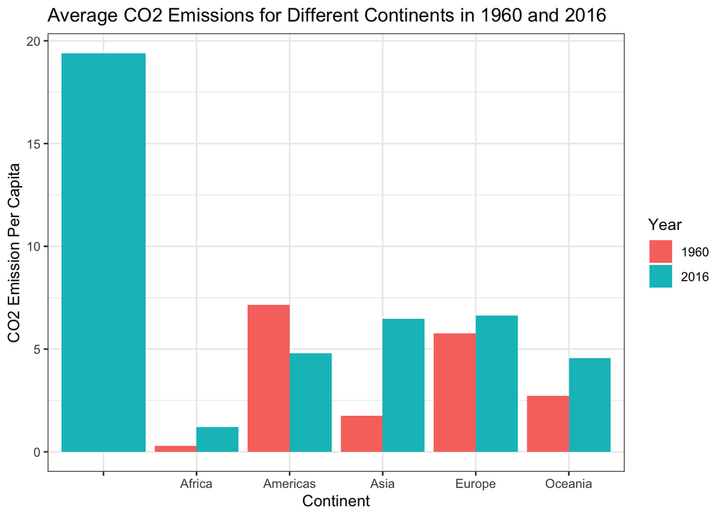

```
## # A tibble: 0 × 25
## # Groups:   region, name [0]
## # … with 25 variables: iso3 <chr>, name <chr>, iso2 <chr>, region <chr>,
## #   sub.region <chr>, intermediate.region <chr>, time <int>,
## #   totalPopulation <int>, fertilityRate <dbl>, lifeExpectancy <dbl>,
## #   childMortality <dbl>, youthFemaleLiteracy <dbl>, youthMaleLiteracy <dbl>,
## #   adultLiteracy <dbl>, GDP_PC <dbl>, accessElectricity <dbl>,
## #   agriculturalLand <dbl>, agricultureTractors <int>, cerealProduction <int>,
## #   fertilizerHa <dbl>, co2 <dbl>, greenhouseGases <dbl>, co2_PC <dbl>, …
```

CO2 emission levels per capita for 2019 are not available.

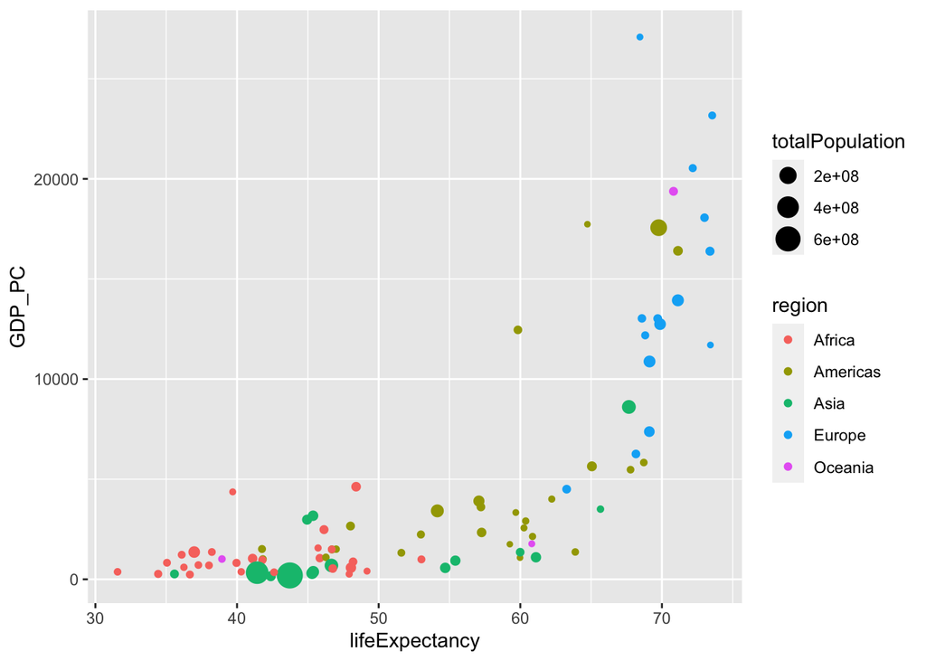

This is a graph of GDP per capita versus life expectancy by country, using data from 1960. Overall, Europe and The Americas seem to have higher GDP per capita values than the other continents. Africa appears to have the lowest.

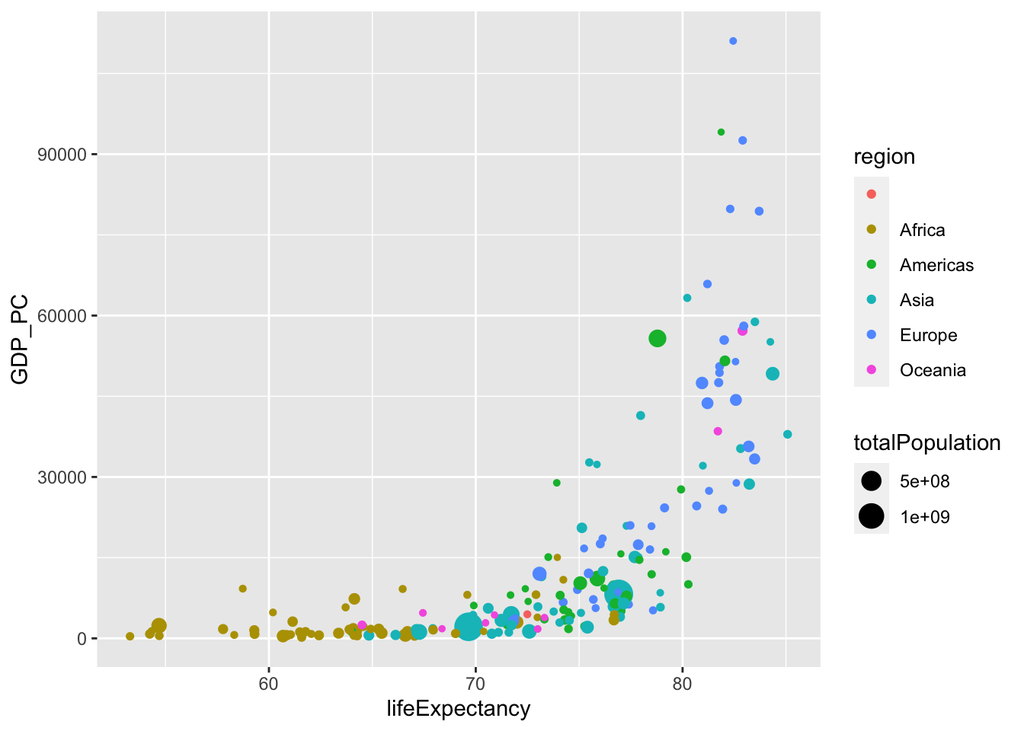

This is a graph of GDP per capita versus life expectancy by country, using data from 2019. The biggest noticeable change is the increase in life expectancy and GDP per capita values overall. Asia also increased in GDP per capita values relative to the other continents.

```
##            Africa Americas     Asia   Europe  Oceania
## 70.73900 41.46600 58.64651 51.64931 68.28254 56.39613
```

These are the average life expectancies based on continent in 1960.

```
##            Africa Americas     Asia   Europe  Oceania
## 77.79056 64.11014 75.83206 74.61739 79.35714 73.52827
```

These are the average life expectancies based on continent in 2019. The relative trends of these life expectancies are reflective of what was shown in the graph.

```
##            LE1960   LE2019 LEGrowth
## ...1     70.73900 77.79056  7.05156
## Europe   68.28254 79.35714 11.07460
## Oceania  56.39613 73.52827 17.13214
## Americas 58.64651 75.83206 17.18555
## Africa   41.46600 64.11014 22.64414
## Asia     51.64931 74.61739 22.96808
```

This table shows that Asia has had the greatest growth in life expectancy from 1960 to 2019, and Europe has had the least.

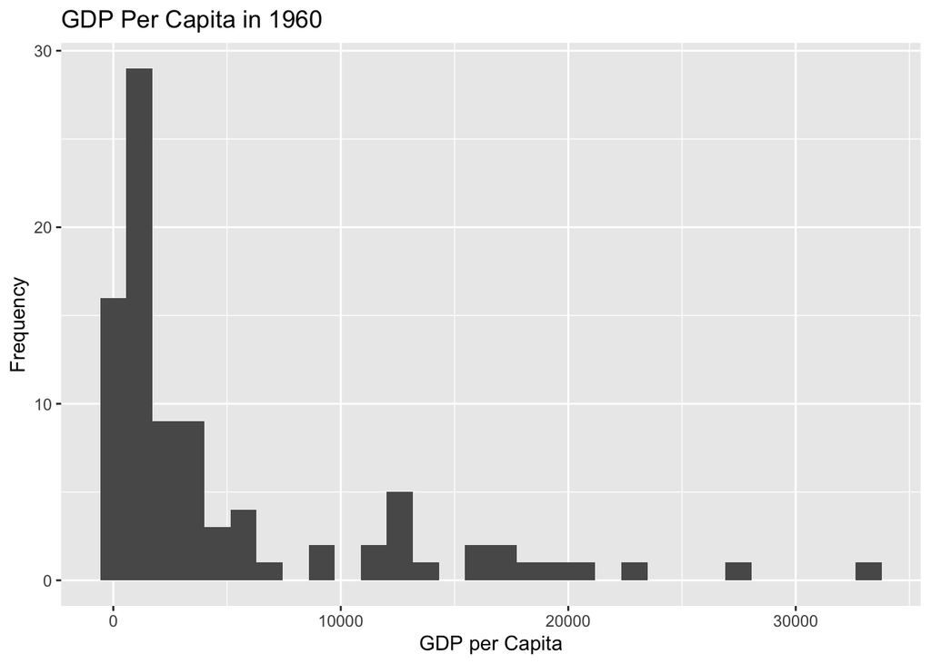

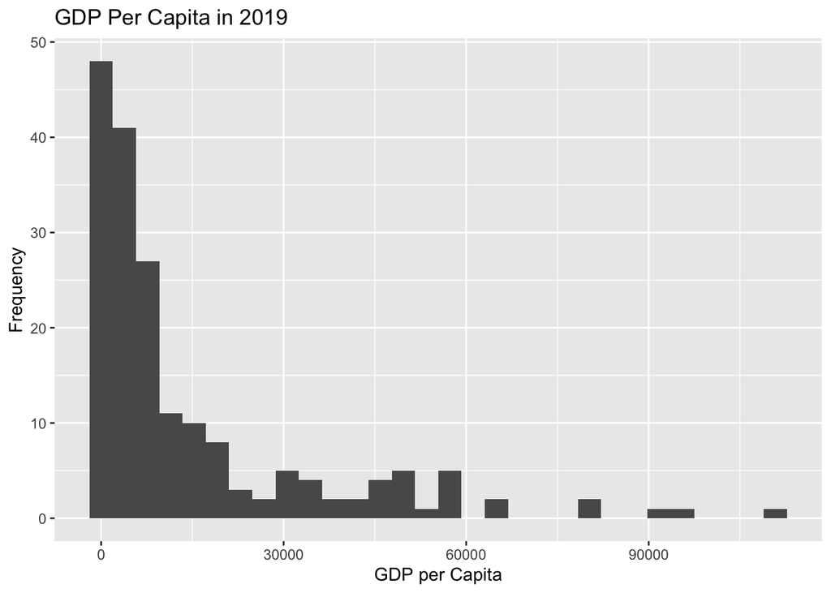

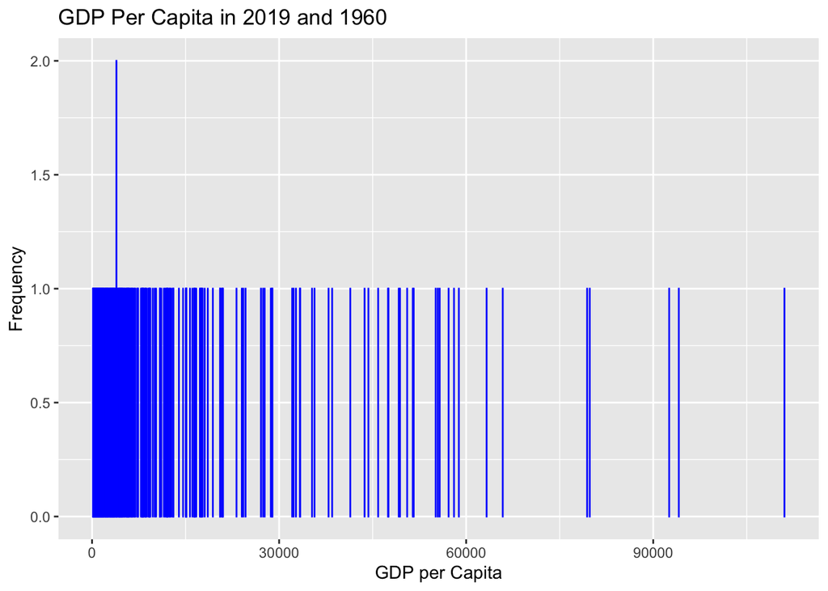

```
## The US was ranked 18th for life expectancy in 1960.
```

```
## The US was ranked 46th for life expectancy in 2019.
```

```
## The relative rank of the US divided by the number of countries that have LE data in 1960 is 0.0952381 for life expectancy in 1960.
```

```
## The relative rank of the US divided by the number of countries that have LE data in 2019 is 0.2335025 for life expectancy in 2019.
```

This PS has taken me 10 and a half hours.